# Part A

## Loading Data

```python
#Importing some libraries
import pandas as pd
import numpy as np
import seaborn as sns
import warnings as wrng
wrng.filterwarnings('ignore')
from sklearn.metrics import classification_report , accuracy_score , confusion_matrix , plot_confusion_matrix
from sklearn.linear_model import Ridge
from sklearn.model_selection import RepeatedKFold
from sklearn.model_selection import GridSearchCV
```

- Taking the given training set of historical data as "Historical_Data"

```python
#Reading the given data
Historical_Data=pd.read_csv('C:\\Users\\Thara Jeni\\Desktop\\ML\\CE802_P3_Data.csv')
Historical_Data
```

|  | F1 | F2 | F3 | F4 | F5 | F6 | F7 | F8 | F9 | F10 | ... | F28 | F29 | F30 | F31 | F32 | F33 | F34 | F35 | F36 | Target |
| --- | --- | --- | --- | --- | --- | --- | --- | --- | --- | --- | --- | --- | --- | --- | --- | --- | --- | --- | --- | --- | --- |
| 0 | 25.46 | -225.08 | -177.02 | 137.97 | Very high | 4.08 | -140.19 | 15882.39 | -3728.44 | -145.22 | ... | -6987.02 | 1137.90 | -76.74 | -2.16 | 4.84 | 20.70 | USA | -413.31 | -1451.18 | 3179.17 |
| 1 | 60.52 | -209.14 | -202.85 | 85.50 | Very high | 16.80 | -248.01 | 10796.76 | -2575.88 | -233.30 | ... | -4631.30 | 1138.32 | -55.38 | -3.84 | 11.47 | 20.94 | Europe | -242.97 | -1583.66 | 2784.99 |
| 2 | 9.27 | -319.00 | -185.33 | 61.49 | Low | 9.12 | -151.20 | 8993.31 | -4532.70 | -176.56 | ... | 439.48 | -120.54 | -82.86 | -12.90 | 1.95 | 17.37 | Europe | -257.25 | -1360.91 | 1174.61 |
| 3 | -41.74 | -233.16 | -206.10 | 114.58 | Very high | 19.23 | -161.76 | 8527.65 | -4896.54 | -108.32 | ... | -1263.93 | 1529.00 | -62.67 | -9.26 | 16.53 | 16.41 | Europe | -419.46 | -744.03 | 453.84 |
| 4 | 68.15 | -279.80 | -172.72 | 95.61 | Very low | 12.33 | -162.03 | 17019.57 | -4590.98 | -143.82 | ... | -700.65 | 834.52 | -76.35 | -11.68 | 13.95 | 18.87 | UK | -353.49 | -1026.62 | -402.80 |
| ... | ... | ... | ... | ... | ... | ... | ... | ... | ... | ... | ... | ... | ... | ... | ... | ... | ... | ... | ... | ... | ... |
| 1495 | 70.79 | -225.74 | -201.90 | 162.08 | Low | 11.04 | -148.25 | 7794.72 | -4582.26 | -180.58 | ... | -3766.37 | 801.56 | -78.15 | -5.34 | 10.01 | 15.35 | Rest | -79.23 | -905.29 | 53.25 |
| 1496 | 59.05 | -214.08 | -128.57 | 110.34 | High | -8.28 | -175.39 | 6060.99 | -6426.56 | -192.32 | ... | 954.59 | 1614.78 | -82.47 | -10.34 | 11.87 | 14.45 | UK | -201.72 | -1895.12 | 1187.95 |
| 1497 | 243.56 | -174.58 | -263.71 | 84.18 | High | 7.98 | -150.14 | 20032.29 | -4297.92 | -117.52 | ... | -4271.82 | 1482.96 | -78.84 | -8.90 | 7.26 | 25.31 | USA | -351.69 | -1088.71 | 3770.53 |
| 1498 | 50.60 | -210.96 | -147.14 | 115.88 | Low | 16.80 | -231.52 | 8320.47 | -3040.20 | -208.70 | ... | 3634.42 | 787.32 | -87.18 | -3.12 | 4.50 | 19.78 | Europe | -370.32 | -1875.01 | 653.00 |
| 1499 | 60.64 | -414.12 | -209.13 | 100.20 | High | 2.37 | -141.84 | 4745.58 | -3767.54 | -204.52 | ... | 4828.19 | 798.84 | -75.33 | -3.16 | 6.55 | 17.21 | Rest | -500.67 | -1488.03 | 975.87 |

1500 rows × 37 columns

## Data Analysis

*Analyzing the given training set of historical data which contains features of each customers & a numerical value representing the variation in the annual expenditure of a customer who had due to increase of the energy cost, where positive sign indicates the customer who spend more and negative sign indicates the customer who spend less.*

```python
print(Historical_Data.shape)
```

```
(1500, 37)
```

```python
Historical_Data.info()
```

```
<class 'pandas.core.frame.DataFrame'>
RangeIndex: 1500 entries, 0 to 1499
Data columns (total 37 columns):
 #   Column  Non-Null Count  Dtype
---  ------  --------------  -----
 0   F1      1500 non-null   float64
 1   F2      1500 non-null   float64
 2   F3      1500 non-null   float64
 3   F4      1500 non-null   float64
 4   F5      1500 non-null   object
 5   F6      1500 non-null   float64
 6   F7      1500 non-null   float64
 7   F8      1500 non-null   float64
 8   F9      1500 non-null   float64
 9   F10     1500 non-null   float64
```

[output cut: 29 more lines]

```python
Historical_Data.head()
```

|  | F1 | F2 | F3 | F4 | F5 | F6 | F7 | F8 | F9 | F10 | ... | F28 | F29 | F30 | F31 | F32 | F33 | F34 | F35 | F36 | Target |
| --- | --- | --- | --- | --- | --- | --- | --- | --- | --- | --- | --- | --- | --- | --- | --- | --- | --- | --- | --- | --- | --- |
| 0 | 25.46 | -225.08 | -177.02 | 137.97 | Very high | 4.08 | -140.19 | 15882.39 | -3728.44 | -145.22 | ... | -6987.02 | 1137.90 | -76.74 | -2.16 | 4.84 | 20.70 | USA | -413.31 | -1451.18 | 3179.17 |
| 1 | 60.52 | -209.14 | -202.85 | 85.50 | Very high | 16.80 | -248.01 | 10796.76 | -2575.88 | -233.30 | ... | -4631.30 | 1138.32 | -55.38 | -3.84 | 11.47 | 20.94 | Europe | -242.97 | -1583.66 | 2784.99 |
| 2 | 9.27 | -319.00 | -185.33 | 61.49 | Low | 9.12 | -151.20 | 8993.31 | -4532.70 | -176.56 | ... | 439.48 | -120.54 | -82.86 | -12.90 | 1.95 | 17.37 | Europe | -257.25 | -1360.91 | 1174.61 |
| 3 | -41.74 | -233.16 | -206.10 | 114.58 | Very high | 19.23 | -161.76 | 8527.65 | -4896.54 | -108.32 | ... | -1263.93 | 1529.00 | -62.67 | -9.26 | 16.53 | 16.41 | Europe | -419.46 | -744.03 | 453.84 |
| 4 | 68.15 | -279.80 | -172.72 | 95.61 | Very low | 12.33 | -162.03 | 17019.57 | -4590.98 | -143.82 | ... | -700.65 | 834.52 | -76.35 | -11.68 | 13.95 | 18.87 | UK | -353.49 | -1026.62 | -402.80 |

5 rows × 37 columns

```python
Historical_Data.describe()
```

|  | F1 | F2 | F3 | F4 | F6 | F7 | F8 | F9 | F10 | F11 | ... | F27 | F28 | F29 | F30 | F31 | F32 | F33 | F35 | F36 | Target |
| --- | --- | --- | --- | --- | --- | --- | --- | --- | --- | --- | --- | --- | --- | --- | --- | --- | --- | --- | --- | --- | --- |
| count | 1500.000000 | 1500.000000 | 1500.000000 | 1500.000000 | 1500.000000 | 1500.000000 | 1500.000000 | 1500.000000 | 1500.000000 | 1500.000000 | ... | 1500.000000 | 1500.000000 | 1500.000000 | 1500.000000 | 1500.000000 | 1500.000000 | 1500.000000 | 1500.000000 | 1500.000000 | 1500.000000 |
| mean | 49.361787 | -209.530120 | -200.023327 | 107.093500 | 14.481180 | -157.306927 | 11470.972200 | -4402.414547 | -169.629347 | 24706.125200 | ... | 7.938667 | -1065.452867 | 891.690960 | -74.581840 | -8.218040 | 11.900560 | 18.324180 | -326.214980 | -1191.986500 | 856.493547 |
| std | 41.155295 | 82.215588 | 41.185646 | 30.352973 | 12.475389 | 42.300767 | 9210.333946 | 845.754592 | 59.791412 | 8924.332099 | ... | 3.658756 | 3018.544636 | 579.053729 | 12.983768 | 5.582196 | 4.332523 | 4.214935 | 90.079627 | 299.256174 | 1222.860406 |
| min | -162.270000 | -556.960000 | -393.320000 | 11.790000 | -39.600000 | -412.790000 | -21849.390000 | -9473.680000 | -365.080000 | -6937.110000 | ... | 0.000000 | -11673.120000 | -1106.120000 | -145.470000 | -35.020000 | -10.350000 | -0.090000 | -637.170000 | -2422.210000 | -2685.920000 |
| 25% | 29.140000 | -251.310000 | -220.295000 | 85.802500 | 7.770000 | -178.617500 | 5268.525000 | -4813.235000 | -209.485000 | 18626.070000 | ... | 6.000000 | -3098.372500 | 513.460000 | -80.400000 | -10.590000 | 9.860000 | 16.220000 | -386.137500 | -1386.100000 | 17.235000 |
| 50% | 49.650000 | -209.010000 | -199.635000 | 107.665000 | 14.160000 | -157.685000 | 11274.165000 | -4415.220000 | -170.560000 | 24601.425000 | ... | 8.000000 | -1031.230000 | 871.410000 | -74.280000 | -6.900000 | 11.900000 | 18.350000 | -325.320000 | -1192.645000 | 624.735000 |
| 75% | 70.155000 | -168.325000 | -177.860000 | 126.560000 | 21.030000 | -136.702500 | 17816.257500 | -3992.115000 | -129.840000 | 30487.492500 | ... | 10.000000 | 849.520000 | 1281.080000 | -68.040000 | -4.195000 | 13.980000 | 20.325000 | -263.640000 | -996.160000 | 1609.167500 |
| max | 243.560000 | 173.340000 | -0.570000 | 219.010000 | 88.230000 | 69.400000 | 38994.540000 | 220.360000 | 47.440000 | 50405.070000 | ... | 20.000000 | 10361.960000 | 3744.480000 | -26.850000 | -0.480000 | 31.520000 | 35.920000 | -11.370000 | -166.580000 | 3836.440000 |

8 rows × 35 columns

```python
Historical_Data.dtypes
```

```
F1        float64
F2        float64
F3        float64
F4        float64
F5         object
F6        float64
F7        float64
F8        float64
F9        float64
F10       float64
F11       float64
F12       float64
F13       float64
F14       float64
F15       float64
F16       float64
F17       float64
F18       float64
F19       float64
F20       float64
F21       float64
F22       float64
F23       float64
F24       float64
F25       float64
F26         int64
F27         int64
F28       float64
F29       float64
F30       float64
F31       float64
F32       float64
F33       float64
F34        object
F35       float64
F36       float64
Target    float64
dtype: object
```

```python
Historical_Data['Target'].value_counts()
```

```
 319.81     2
-141.66     2
 73.19      2
 3179.17    1
 369.75     1
           ..
 733.05     1
 778.84     1
 780.60     1
 1426.46    1
 975.87     1
Name: Target, Length: 1497, dtype: int64
```

# Pre-Processing

##### Missing Data

```python
Historical_Data.isnull().sum()
```

```
F1        0
F2        0
F3        0
F4        0
F5        0
F6        0
F7        0
F8        0
F9        0
F10       0
F11       0
F12       0
F13       0
F14       0
F15       0
F16       0
F17       0
F18       0
F19       0
F20       0
F21       0
F22       0
F23       0
F24       0
F25       0
F26       0
F27       0
F28       0
F29       0
F30       0
F31       0
F32       0
F33       0
F34       0
F35       0
F36       0
Target    0
dtype: int64
```

#### Categorical Values

```python
Historical_Data['F5'].unique()
```

```
array(['Very high', 'Low', 'Very low', 'Medium', 'High'], dtype=object)
```

```python
Historical_Data['F5'].value_counts()
```

```
Very low     307
High         307
Very high    306
Medium       294
Low          286
Name: F5, dtype: int64
```

```python
Historical_Data['F34'].unique()
```

```
array(['USA', 'Europe', 'UK', 'Rest'], dtype=object)
```

```python
Historical_Data['F34'].value_counts()
```

```
Europe    393
USA       378
Rest      365
UK        364
Name: F34, dtype: int64
```

```python
cleanup = {"F5": {"Very low":-2, "Low":-1, "Medium":0, "High" : 1, "Very high":2}}
Historical_Data.replace(cleanup, inplace=True)
Historical_Data.head()
```

|  | F1 | F2 | F3 | F4 | F5 | F6 | F7 | F8 | F9 | F10 | ... | F28 | F29 | F30 | F31 | F32 | F33 | F34 | F35 | F36 | Target |
| --- | --- | --- | --- | --- | --- | --- | --- | --- | --- | --- | --- | --- | --- | --- | --- | --- | --- | --- | --- | --- | --- |
| 0 | 25.46 | -225.08 | -177.02 | 137.97 | 2 | 4.08 | -140.19 | 15882.39 | -3728.44 | -145.22 | ... | -6987.02 | 1137.90 | -76.74 | -2.16 | 4.84 | 20.70 | USA | -413.31 | -1451.18 | 3179.17 |
| 1 | 60.52 | -209.14 | -202.85 | 85.50 | 2 | 16.80 | -248.01 | 10796.76 | -2575.88 | -233.30 | ... | -4631.30 | 1138.32 | -55.38 | -3.84 | 11.47 | 20.94 | Europe | -242.97 | -1583.66 | 2784.99 |
| 2 | 9.27 | -319.00 | -185.33 | 61.49 | -1 | 9.12 | -151.20 | 8993.31 | -4532.70 | -176.56 | ... | 439.48 | -120.54 | -82.86 | -12.90 | 1.95 | 17.37 | Europe | -257.25 | -1360.91 | 1174.61 |
| 3 | -41.74 | -233.16 | -206.10 | 114.58 | 2 | 19.23 | -161.76 | 8527.65 | -4896.54 | -108.32 | ... | -1263.93 | 1529.00 | -62.67 | -9.26 | 16.53 | 16.41 | Europe | -419.46 | -744.03 | 453.84 |
| 4 | 68.15 | -279.80 | -172.72 | 95.61 | -2 | 12.33 | -162.03 | 17019.57 | -4590.98 | -143.82 | ... | -700.65 | 834.52 | -76.35 | -11.68 | 13.95 | 18.87 | UK | -353.49 | -1026.62 | -402.80 |

5 rows × 37 columns

```python
Cleaned_Historical_Data = pd.get_dummies(Historical_Data, columns=['F34'])
Cleaned_Historical_Data.head()
```

|  | F1 | F2 | F3 | F4 | F5 | F6 | F7 | F8 | F9 | F10 | ... | F31 | F32 | F33 | F35 | F36 | Target | F34_Europe | F34_Rest | F34_UK | F34_USA |
| --- | --- | --- | --- | --- | --- | --- | --- | --- | --- | --- | --- | --- | --- | --- | --- | --- | --- | --- | --- | --- | --- |
| 0 | 25.46 | -225.08 | -177.02 | 137.97 | 2 | 4.08 | -140.19 | 15882.39 | -3728.44 | -145.22 | ... | -2.16 | 4.84 | 20.70 | -413.31 | -1451.18 | 3179.17 | 0 | 0 | 0 | 1 |
| 1 | 60.52 | -209.14 | -202.85 | 85.50 | 2 | 16.80 | -248.01 | 10796.76 | -2575.88 | -233.30 | ... | -3.84 | 11.47 | 20.94 | -242.97 | -1583.66 | 2784.99 | 1 | 0 | 0 | 0 |
| 2 | 9.27 | -319.00 | -185.33 | 61.49 | -1 | 9.12 | -151.20 | 8993.31 | -4532.70 | -176.56 | ... | -12.90 | 1.95 | 17.37 | -257.25 | -1360.91 | 1174.61 | 1 | 0 | 0 | 0 |
| 3 | -41.74 | -233.16 | -206.10 | 114.58 | 2 | 19.23 | -161.76 | 8527.65 | -4896.54 | -108.32 | ... | -9.26 | 16.53 | 16.41 | -419.46 | -744.03 | 453.84 | 1 | 0 | 0 | 0 |
| 4 | 68.15 | -279.80 | -172.72 | 95.61 | -2 | 12.33 | -162.03 | 17019.57 | -4590.98 | -143.82 | ... | -11.68 | 13.95 | 18.87 | -353.49 | -1026.62 | -402.80 | 0 | 0 | 1 | 0 |

5 rows × 40 columns

```python
Historical_Data.dtypes
```

```
F1        float64
F2        float64
F3        float64
F4        float64
F5          int64
F6        float64
F7        float64
F8        float64
F9        float64
F10       float64
F11       float64
F12       float64
F13       float64
F14       float64
F15       float64
F16       float64
F17       float64
F18       float64
F19       float64
F20       float64
F21       float64
F22       float64
F23       float64
F24       float64
F25       float64
F26         int64
F27         int64
F28       float64
F29       float64
F30       float64
F31       float64
F32       float64
F33       float64
F34        object
F35       float64
F36       float64
Target    float64
dtype: object
```

```python
import numpy as np
X = Cleaned_Historical_Data.loc[:, Cleaned_Historical_Data.columns != 'Target'].to_numpy()
Y = Cleaned_Historical_Data.loc[:, 'Target'].to_numpy()
print(X.shape, Y.shape)
```

```
(1500, 39) (1500,)
```

# Cross-validation

```python
from sklearn.model_selection import KFold, cross_val_score

k_fold = KFold(n_splits=5)
for train_indices, test_indices in k_fold.split(X):
    print('Train: %s | test: %s' % (train_indices, test_indices))
```

```
Train: [ 300  301  302 ... 1497 1498 1499] | test: [  0   1   2   3   4   5   6   7   8   9  10  11  12  13  14  15  16  17
  18  19  20  21  22  23  24  25  26  27  28  29  30  31  32  33  34  35
  36  37  38  39  40  41  42  43  44  45  46  47  48  49  50  51  52  53
  54  55  56  57  58  59  60  61  62  63  64  65  66  67  68  69  70  71
  72  73  74  75  76  77  78  79  80  81  82  83  84  85  86  87  88  89
  90  91  92  93  94  95  96  97  98  99 100 101 102 103 104 105 106 107
 108 109 110 111 112 113 114 115 116 117 118 119 120 121 122 123 124 125
 126 127 128 129 130 131 132 133 134 135 136 137 138 139 140 141 142 143
 144 145 146 147 148 149 150 151 152 153 154 155 156 157 158 159 160 161
 162 163 164 165 166 167 168 169 170 171 172 173 174 175 176 177 178 179
 180 181 182 183 184 185 186 187 188 189 190 191 192 193 194 195 196 197
 198 199 200 201 202 203 204 205 206 207 208 209 210 211 212 213 214 215
 216 217 218 219 220 221 222 223 224 225 226 227 228 229 230 231 232 233
 234 235 236 237 238 239 240 241 242 243 244 245 246 247 248 249 250 251
 252 253 254 255 256 257 258 259 260 261 262 263 264 265 266 267 268 269
```

[output cut: 80 more lines]

##### Data Driven

```python
k_fold = KFold(n_splits=5)
for train_indices, test_indices in k_fold.split(X):
    print(np.nanmean(X[train_indices, 1]))
```

```
-208.95448333333334
-210.95268333333334
-210.47948333333335
-208.60785
-208.6561
```

# Correlation

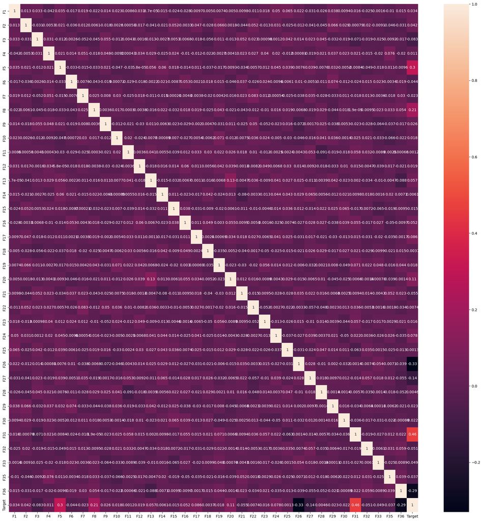

```python
#Plotting Correlation
import matplotlib.pyplot as plt
%matplotlib inline

plt.figure(figsize=(25,25))
correlation=Historical_Data.corr()
sns.heatmap(correlation,xticklabels=correlation.columns,yticklabels=correlation.columns,annot=True)
```

## Data transformation

#### Scaling and Normalization

```python
from sklearn.preprocessing import StandardScaler
k_fold = KFold(n_splits=5)
X_or = X.copy() # We make a copy of our data to avoid overwriting
for train_indices, test_indices in k_fold.split(X):
    mean = np.nanmean(X_or[train_indices, 1])
    X[np.isnan(X_or[:,1]), 1] = mean # We substitute the missing values for the mean
    ss = StandardScaler()
    ss.fit(X[train_indices, :])
    X_train = ss.transform(X[train_indices, :])
    X_test = ss.transform(X[test_indices, :])
```

```python
import numpy as np
import matplotlib as mpb
from sklearn.model_selection import train_test_split


X_train,X_test,Y_train,Y_test = train_test_split (X,Y,test_size=0.20, random_state=0)

from sklearn import preprocessing
from sklearn.preprocessing import MinMaxScaler

MMS = MinMaxScaler()
X_train=MMS.fit_transform(X_train)
X_test=MMS.fit_transform(X_test)
```

# Hyperparameter tuning on Multiple Models – Regression

```python
from sklearn.metrics import explained_variance_score,mean_absolute_error,r2_score
from time import time
from sklearn.linear_model import LinearRegression,Ridge,Lasso
from sklearn.neighbors import KNeighborsRegressor
from sklearn.ensemble import RandomForestRegressor
from sklearn.tree import DecisionTreeRegressor
from sklearn.svm import SVR
```

```python
regressors = [
    RandomForestRegressor(),
    DecisionTreeRegressor(),
    LinearRegression(),
    SVR()
]
```

```python
head = 10
for model in regressors[:head]:
    start = time()
    model.fit(X_train, Y_train)
    train_time = time() - start
    start = time()
    Y_pred = model.predict(X_test)
    predict_time = time()-start
    print(model)
    print("\tTraining time: %0.3fs" % train_time)
    print("\tPrediction time: %0.3fs" % predict_time)
    print("\tExplained variance:", explained_variance_score(Y_test, Y_pred))
    print("\tMean absolute error:", mean_absolute_error(Y_test, Y_pred))
    print("\tR2 score:", r2_score(Y_test, Y_pred))
    print()
```

```
RandomForestRegressor()
	Training time: 2.887s
	Prediction time: 0.016s
	Explained variance: 0.6670223381228377
	Mean absolute error: 592.2012543333334
	R2 score: 0.6406609519112725

DecisionTreeRegressor()
	Training time: 0.035s
	Prediction time: 0.000s
	Explained variance: 0.25177582702783274
	Mean absolute error: 804.2902333333334
	R2 score: 0.2215130999588073

LinearRegression()
	Training time: 0.031s
	Prediction time: 0.000s
	Explained variance: 0.6845000159668364
	Mean absolute error: 570.6678333333333
	R2 score: 0.6827794462535388

SVR()
	Training time: 0.184s
	Prediction time: 0.066s
	Explained variance: 0.013406738244474248
	Mean absolute error: 993.7505852719011
	R2 score: 0.00019862151808713868
```

# Investigating performance of ML Techniques

*Here we are investigating the performance of three Machine Learning Procedures such are:*

- Linear Regression
- Random Forest Regressor
- Decision tree regressor

```python
# Model Evaluation Metrics
import sklearn.metrics as metrics
from sklearn.metrics import mean_absolute_error
from sklearn.metrics import mean_squared_error
from sklearn.metrics import r2_score
from sklearn.model_selection import GridSearchCV
```

## Linear Regression Model

```python
#Modeling
# Linear Regression
from sklearn.linear_model import LinearRegression
regressor = LinearRegression()
regressor.fit(X_train, Y_train)

pred_regressor = regressor.predict(X_test)

print('Mean Absolute Error:', metrics.mean_absolute_error(Y_test, pred_regressor))
print('Mean Squared Error:', metrics.mean_squared_error(Y_test, pred_regressor))
print('Root Mean Squared Error:', np.sqrt(metrics.mean_squared_error(Y_test, pred_regressor)))
print('intercept of the simple linear fit:', regressor.intercept_)

# Calculating the r2 score
r2_LRM = r2_score(Y_test, pred_regressor)
print("r2 score_LRM :", r2_LRM)
```

```
Mean Absolute Error: 570.6678333333333
Mean Squared Error: 504431.94375166664
Root Mean Squared Error: 710.2337247355033
intercept of the simple linear fit: 1.1698437846477018e+16
r2 score_LRM : 0.6827794462535388
```

```python
print('slope of the simple linear fit of the data :')
regressor.coef_
```

```
slope of the simple linear fit of the data :
```

```
array([ 2.83704475e+02,  1.42581293e+02, -1.80704546e+02, -3.99354083e+01,
        1.05167884e+03,  6.62374978e+00, -2.12535960e+01,  1.74638369e+03,
       -1.42924547e+02, -1.63646913e+01, -1.70391111e+02,  2.75411081e+01,
       -2.92663101e+01,  6.94506464e+01, -2.43022507e+02,  3.20918367e+01,
        4.07656923e+02,  5.48032938e+01, -3.45312393e+00,  3.52430169e+03,
       -8.26444910e+01, -3.39837274e+02,  2.08713289e+01,  2.07018033e+02,
       -2.10397862e+02, -2.60787667e+03, -9.77650383e+02, -6.51017546e+01,
       -1.40984496e+02, -1.07556539e+02,  3.46044712e+03, -7.90619348e+01,
       -1.18576952e+01, -3.80858027e+02, -3.08471045e+03, -1.16984378e+16,
       -1.16984378e+16, -1.16984378e+16, -1.16984378e+16])
```

```python
regressor.get_params()
```

```
{'copy_X': True,
 'fit_intercept': True,
 'n_jobs': None,
 'normalize': 'deprecated',
 'positive': False}
```

#### GridSearchCV for Linear Regression

```python
params={
    'copy_X' : ['True','False'],
    'fit_intercept' : ['True','False'],
    'n_jobs' : [None, 'sqrt', 'log2', 0.2, 0.4, 0.6, 0.8],
    'positive' : ['False', 'True'],
    'normalize' :['deprecated','True','False']}

clf=GridSearchCV(estimator= LinearRegression(),param_grid=params,cv=5,n_jobs=5,verbose=1)

clf.fit(X_train,Y_train)
print(clf.best_params_)
```

```
Fitting 5 folds for each of 168 candidates, totalling 840 fits
{'copy_X': 'True', 'fit_intercept': 'True', 'n_jobs': None, 'normalize': 'deprecated', 'positive': 'False'}
```

Here, the obtained best Parameters of Linear regression are the same as their default parameters.And also after GridSearchCV, we obtained the same score,so proceeding with the obtained Linear Regression score.

```python
# table
from tabulate import tabulate
table_data =[ ['Regression','Scores'],
             ['LinearRegression' , r2_LRM ],
             ]
print(tabulate(table_data, headers= "firstrow", tablefmt="fancy_grid" ))
```

```
╒══════════════════╤══════════╕
│ Regression       │   Scores │
╞══════════════════╪══════════╡
│ LinearRegression │ 0.682779 │
╘══════════════════╧══════════╛
```

From above score, we obtained the best Linear Regression Score(68%).

## Random Forest Regression

```python
from sklearn.ensemble import RandomForestRegressor
rfr = RandomForestRegressor()
rfr.fit(X_train, Y_train)

pred_rfr = rfr.predict(X_test)
print('Mean Absolute Error:', metrics.mean_absolute_error(Y_test, pred_rfr))
print('Mean Squared Error:', metrics.mean_squared_error(Y_test, pred_rfr))
print('Root Mean Squared Error:', np.sqrt(metrics.mean_squared_error(Y_test, pred_rfr)))

# Calculating the r2 score
r2_RFR = r2_score(Y_test, pred_rfr)
print("r2 score_RFR :", r2_RFR)
```

```
Mean Absolute Error: 593.1715370000001
Mean Squared Error: 589106.9976482796
Root Mean Squared Error: 767.5330596451723
r2 score_RFR : 0.6295301074312959
```

```python
rfr.get_params()
```

```
{'bootstrap': True,
 'ccp_alpha': 0.0,
 'criterion': 'squared_error',
 'max_depth': None,
 'max_features': 'auto',
 'max_leaf_nodes': None,
 'max_samples': None,
 'min_impurity_decrease': 0.0,
 'min_samples_leaf': 1,
 'min_samples_split': 2,
 'min_weight_fraction_leaf': 0.0,
 'n_estimators': 100,
 'n_jobs': None,
 'oob_score': False,
 'random_state': None,
 'verbose': 0,
 'warm_start': False}
```

#### GridSearchCV for Random Forest Regression

```python
params = {'bootstrap': [True],
              'max_depth': [50, 70, 90, 120],
              'max_features':[2, 3, 4],
              'min_samples_leaf': [4, 5, 6],
              'n_estimators': [100,200,300,500]}

grid = GridSearchCV(estimator = rfr, param_grid = params, cv=3, n_jobs = -1, verbose = 2)

grid.fit(X_train,Y_train)
print(grid.best_params_)
```

[output not shown]

```python
from sklearn.ensemble import RandomForestRegressor
rfr_1 = RandomForestRegressor(bootstrap=True,max_depth=70,max_features=4,min_samples_leaf=4,n_estimators=500)
rfr_1.fit(X_train, Y_train)

pred_rfr_1 = rfr_1.predict(X_test)
print('Mean Absolute Error:', metrics.mean_absolute_error(Y_test, pred_rfr_1))
print('Mean Squared Error:', metrics.mean_squared_error(Y_test, pred_rfr_1))
print('Root Mean Squared Error:', np.sqrt(metrics.mean_squared_error(Y_test, pred_rfr_1)))

# Calculating the r2 score
r2_RFR_1 = r2_score(Y_test, pred_rfr_1)
print("r2 score_RFR :", r2_RFR_1)
```

```
Mean Absolute Error: 737.8201654455438
Mean Squared Error: 832874.6847854016
Root Mean Squared Error: 912.6196824446652
r2 score_RFR : 0.4762326772090719
```

#### Comparing the obtained Random Forest Regression scores

```python
# table
from tabulate import tabulate
table_data =[ ['Random Forest Regressor','Scores'],
             ['Before GridSearchCV' , r2_RFR ],
             ['After GridSearchCV' ,  r2_RFR_1]
            ]
print(tabulate(table_data, headers= "firstrow", tablefmt="fancy_grid" ))
```

```
╒═══════════════════════════╤══════════╕
│ Random Forest Regressor   │   Scores │
╞═══════════════════════════╪══════════╡
│ Before GridSearchCV       │ 0.62953  │
├───────────────────────────┼──────────┤
│ After GridSearchCV        │ 0.476233 │
╘═══════════════════════════╧══════════╛
```

From above scores, we obtained Random Forest Regression Score before GridSearchCV(63%) as best.

## Decision Tree Regressor

```python
from sklearn.tree import DecisionTreeRegressor
DTR = DecisionTreeRegressor() # creating Gradient Boosting Regressor object
DTR.fit(X_train,Y_train) #feeding the model
pred_DTR = DTR.predict(X_test)
print('Mean Absolute Error:', metrics.mean_absolute_error(Y_test, pred_DTR))
print('Mean Squared Error:', metrics.mean_squared_error(Y_test, pred_DTR))
print('Root Mean Squared Error:', np.sqrt(metrics.mean_squared_error(Y_test, pred_DTR)))

# Calculating the r2 score
r2_DTR = r2_score(Y_test, pred_DTR)
print("r2_GBR score :", r2_DTR)
```

```
Mean Absolute Error: 780.6587666666667
Mean Squared Error: 1153475.3143690003
Root Mean Squared Error: 1073.9996808048875
r2_GBR score : 0.27461755249753894
```

```python
DTR.get_params()
```

```
{'ccp_alpha': 0.0,
 'criterion': 'squared_error',
 'max_depth': None,
 'max_features': None,
 'max_leaf_nodes': None,
 'min_impurity_decrease': 0.0,
 'min_samples_leaf': 1,
 'min_samples_split': 2,
 'min_weight_fraction_leaf': 0.0,
 'random_state': None,
 'splitter': 'best'}
```

#### GridSearchCV for Decision Tree Regression

```python
params= {'criterion': ['squared_error','gini'],
          'max_depth': range(1, 10),
          'min_samples_split': range(10, 30, 10)}

grid = GridSearchCV(estimator=DTR,param_grid = params,cv=5,n_jobs=-1,scoring='neg_mean_squared_error')

grid.fit(X_train, Y_train)
print(grid.best_params_)
```

```
{'criterion': 'squared_error', 'max_depth': 7, 'min_samples_split': 20}
```

```python
from sklearn.tree import DecisionTreeRegressor
DTR_1 = DecisionTreeRegressor(criterion='squared_error',max_depth=7,min_samples_split=20) # creating Gradient Boosting Regressor object
DTR_1.fit(X_train,Y_train) #feeding the model
pred_DTR_1 = DTR_1.predict(X_test)
print('Mean Absolute Error:', metrics.mean_absolute_error(Y_test, pred_DTR_1))
print('Mean Squared Error:', metrics.mean_squared_error(Y_test, pred_DTR_1))
print('Root Mean Squared Error:', np.sqrt(metrics.mean_squared_error(Y_test, pred_DTR_1)))

# Calculating the r2 score
r2_DTR_1 = r2_score(Y_test, pred_DTR_1)
print("r2_GBR_1 score :", r2_DTR_1)
```

```
Mean Absolute Error: 713.6238553759755
Mean Squared Error: 984679.503280312
Root Mean Squared Error: 992.310185012888
r2_GBR_1 score : 0.3807676512906426
```

#### Comparing the obtained Decision Tree Regression scores

```python
# table
from tabulate import tabulate
table_data =[ ['Decision Tree Regressor','Scores'],
             ['Before GridSearchCV' , r2_DTR ],
             ['After GridSearchCV' ,  r2_DTR_1]
            ]
print(tabulate(table_data, headers= "firstrow", tablefmt="fancy_grid" ))
```

```
╒═══════════════════════════╤══════════╕
│ Decision Tree Regressor   │   Scores │
╞═══════════════════════════╪══════════╡
│ Before GridSearchCV       │ 0.274618 │
├───────────────────────────┼──────────┤
│ After GridSearchCV        │ 0.380768 │
╘═══════════════════════════╧══════════╛
```

## Predictive Analysis

### Comparing the performance of Regression Models

```python
# table
from tabulate import tabulate
table_data = [['Regressors','Scores'],
             ['Linear Regression' , r2_LRM  ],
             ['Random Forest Regression' ,  r2_RFR_1],
             ['Decision Tree Regressor',r2_DTR]
            ]
print(tabulate(table_data, headers= "firstrow", tablefmt="fancy_grid" ))
```

```
╒══════════════════════════╤══════════╕
│ Regressors               │   Scores │
╞══════════════════════════╪══════════╡
│ Linear Regression        │ 0.682779 │
├──────────────────────────┼──────────┤
│ Random Forest Regression │ 0.476233 │
├──────────────────────────┼──────────┤
│ Decision Tree Regressor  │ 0.274618 │
╘══════════════════════════╧══════════╛
```

# Part B

### Prediction on a hold-out test set

```python
# Load the test data
test_df = pd.read_csv('C:\\Users\\Thara Jeni\\Desktop\\ML\\CE802_P3_Test.csv')
test_df
```

|  | F1 | F2 | F3 | F4 | F5 | F6 | F7 | F8 | F9 | F10 | ... | F28 | F29 | F30 | F31 | F32 | F33 | F34 | F35 | F36 | Target |
| --- | --- | --- | --- | --- | --- | --- | --- | --- | --- | --- | --- | --- | --- | --- | --- | --- | --- | --- | --- | --- | --- |
| 0 | 43.32 | -186.00 | -222.53 | 87.83 | High | 14.85 | -109.49 | 5648.04 | -3589.64 | -196.44 | ... | 4925.20 | 2028.74 | -73.92 | -6.70 | 7.88 | 17.80 | Europe | -192.90 | -912.06 | NaN |
| 1 | 40.06 | -80.16 | -233.96 | 78.11 | Very low | 19.47 | -147.48 | 19604.82 | -6077.54 | -150.54 | ... | -3169.06 | 197.22 | -74.04 | -3.36 | 14.71 | 12.56 | UK | -272.52 | -1500.16 | NaN |
| 2 | 13.19 | -173.50 | -173.52 | 95.18 | High | -19.47 | -162.54 | 19426.29 | -4573.22 | -162.06 | ... | -4993.31 | 1210.08 | -60.42 | -2.34 | 15.36 | 17.69 | Rest | -304.50 | -1674.76 | NaN |
| 3 | 55.10 | -45.82 | -236.11 | 128.31 | Medium | 16.05 | -150.76 | 19828.65 | -4126.90 | -88.62 | ... | 2343.70 | 940.92 | -112.68 | -5.30 | 9.24 | 18.61 | Europe | -399.24 | -1074.56 | NaN |
| 4 | -5.31 | -234.50 | -179.52 | 137.01 | Medium | 15.78 | -109.02 | 12212.55 | -4805.98 | -140.72 | ... | -6372.64 | 950.14 | -95.40 | -2.26 | 20.73 | 18.49 | Europe | -254.19 | -1013.19 | NaN |
| ... | ... | ... | ... | ... | ... | ... | ... | ... | ... | ... | ... | ... | ... | ... | ... | ... | ... | ... | ... | ... | ... |
| 1495 | 90.78 | -348.22 | -249.61 | 63.44 | Very low | 13.92 | -202.22 | 14534.07 | -4182.72 | -69.86 | ... | -667.79 | 2257.88 | -51.75 | -3.92 | 13.36 | 17.34 | Europe | -336.96 | -1001.77 | NaN |
| 1496 | 65.83 | -221.82 | -200.91 | 46.47 | Very high | 28.86 | -154.99 | 17578.95 | -4350.82 | -163.92 | ... | 69.09 | 1055.32 | -78.87 | -7.96 | 15.02 | 17.77 | UK | -296.13 | -862.31 | NaN |
| 1497 | 67.92 | -202.38 | -179.05 | 73.39 | High | 16.50 | -138.76 | 13908.39 | -4237.08 | -204.00 | ... | 657.63 | 588.96 | -91.74 | -1.48 | 12.39 | 20.85 | UK | -296.04 | -930.60 | NaN |
| 1498 | 100.95 | -206.76 | -193.71 | 89.88 | Low | 14.55 | -177.76 | 8657.19 | -3177.04 | -151.20 | ... | -924.83 | -4.98 | -74.55 | -10.86 | 23.75 | 15.31 | Rest | -228.21 | -1321.47 | NaN |
| 1499 | 30.33 | -314.10 | -169.36 | 76.16 | High | 8.10 | -94.45 | 2445.15 | -4551.54 | -195.74 | ... | -2716.81 | 1321.66 | -69.42 | -12.48 | 11.91 | 20.83 | Rest | -370.32 | -1072.37 | NaN |

1500 rows × 37 columns

```python
# Make sure you work on a copy
test_data = test_df.iloc[:,:-1].copy()
test_data.head()
```

|  | F1 | F2 | F3 | F4 | F5 | F6 | F7 | F8 | F9 | F10 | ... | F27 | F28 | F29 | F30 | F31 | F32 | F33 | F34 | F35 | F36 |
| --- | --- | --- | --- | --- | --- | --- | --- | --- | --- | --- | --- | --- | --- | --- | --- | --- | --- | --- | --- | --- | --- |
| 0 | 43.32 | -186.00 | -222.53 | 87.83 | High | 14.85 | -109.49 | 5648.04 | -3589.64 | -196.44 | ... | 12 | 4925.20 | 2028.74 | -73.92 | -6.70 | 7.88 | 17.80 | Europe | -192.90 | -912.06 |
| 1 | 40.06 | -80.16 | -233.96 | 78.11 | Very low | 19.47 | -147.48 | 19604.82 | -6077.54 | -150.54 | ... | 8 | -3169.06 | 197.22 | -74.04 | -3.36 | 14.71 | 12.56 | UK | -272.52 | -1500.16 |
| 2 | 13.19 | -173.50 | -173.52 | 95.18 | High | -19.47 | -162.54 | 19426.29 | -4573.22 | -162.06 | ... | 6 | -4993.31 | 1210.08 | -60.42 | -2.34 | 15.36 | 17.69 | Rest | -304.50 | -1674.76 |
| 3 | 55.10 | -45.82 | -236.11 | 128.31 | Medium | 16.05 | -150.76 | 19828.65 | -4126.90 | -88.62 | ... | 14 | 2343.70 | 940.92 | -112.68 | -5.30 | 9.24 | 18.61 | Europe | -399.24 | -1074.56 |
| 4 | -5.31 | -234.50 | -179.52 | 137.01 | Medium | 15.78 | -109.02 | 12212.55 | -4805.98 | -140.72 | ... | 10 | -6372.64 | 950.14 | -95.40 | -2.26 | 20.73 | 18.49 | Europe | -254.19 | -1013.19 |

5 rows × 36 columns

##### Pre-processing the test data

```python
test_data['F5'].unique()
```

```
array(['High', 'Very low', 'Medium', 'Very high', 'Low'], dtype=object)
```

```python
test_data['F5'].value_counts()
```

```
High         308
Very low     308
Medium       307
Low          300
Very high    277
Name: F5, dtype: int64
```

```python
test_data['F34'].unique()
```

```
array(['Europe', 'UK', 'Rest', 'USA'], dtype=object)
```

```python
test_data['F34'].value_counts()
```

```
USA       387
UK        383
Europe    382
Rest      348
Name: F34, dtype: int64
```

```python
cleanup = {"F5": {"Very low":-2, "Low":-1, "Medium":0, "High" : 1, "Very high":2}}
test_data.replace(cleanup, inplace=True)
test_data.head()
```

|  | F1 | F2 | F3 | F4 | F5 | F6 | F7 | F8 | F9 | F10 | ... | F27 | F28 | F29 | F30 | F31 | F32 | F33 | F34 | F35 | F36 |
| --- | --- | --- | --- | --- | --- | --- | --- | --- | --- | --- | --- | --- | --- | --- | --- | --- | --- | --- | --- | --- | --- |
| 0 | 43.32 | -186.00 | -222.53 | 87.83 | 1 | 14.85 | -109.49 | 5648.04 | -3589.64 | -196.44 | ... | 12 | 4925.20 | 2028.74 | -73.92 | -6.70 | 7.88 | 17.80 | Europe | -192.90 | -912.06 |
| 1 | 40.06 | -80.16 | -233.96 | 78.11 | -2 | 19.47 | -147.48 | 19604.82 | -6077.54 | -150.54 | ... | 8 | -3169.06 | 197.22 | -74.04 | -3.36 | 14.71 | 12.56 | UK | -272.52 | -1500.16 |
| 2 | 13.19 | -173.50 | -173.52 | 95.18 | 1 | -19.47 | -162.54 | 19426.29 | -4573.22 | -162.06 | ... | 6 | -4993.31 | 1210.08 | -60.42 | -2.34 | 15.36 | 17.69 | Rest | -304.50 | -1674.76 |
| 3 | 55.10 | -45.82 | -236.11 | 128.31 | 0 | 16.05 | -150.76 | 19828.65 | -4126.90 | -88.62 | ... | 14 | 2343.70 | 940.92 | -112.68 | -5.30 | 9.24 | 18.61 | Europe | -399.24 | -1074.56 |
| 4 | -5.31 | -234.50 | -179.52 | 137.01 | 0 | 15.78 | -109.02 | 12212.55 | -4805.98 | -140.72 | ... | 10 | -6372.64 | 950.14 | -95.40 | -2.26 | 20.73 | 18.49 | Europe | -254.19 | -1013.19 |

5 rows × 36 columns

```python
cleaned_test_data = pd.get_dummies(test_data, columns=['F34'])
cleaned_test_data.head()
```

|  | F1 | F2 | F3 | F4 | F5 | F6 | F7 | F8 | F9 | F10 | ... | F30 | F31 | F32 | F33 | F35 | F36 | F34_Europe | F34_Rest | F34_UK | F34_USA |
| --- | --- | --- | --- | --- | --- | --- | --- | --- | --- | --- | --- | --- | --- | --- | --- | --- | --- | --- | --- | --- | --- |
| 0 | 43.32 | -186.00 | -222.53 | 87.83 | 1 | 14.85 | -109.49 | 5648.04 | -3589.64 | -196.44 | ... | -73.92 | -6.70 | 7.88 | 17.80 | -192.90 | -912.06 | 1 | 0 | 0 | 0 |
| 1 | 40.06 | -80.16 | -233.96 | 78.11 | -2 | 19.47 | -147.48 | 19604.82 | -6077.54 | -150.54 | ... | -74.04 | -3.36 | 14.71 | 12.56 | -272.52 | -1500.16 | 0 | 0 | 1 | 0 |
| 2 | 13.19 | -173.50 | -173.52 | 95.18 | 1 | -19.47 | -162.54 | 19426.29 | -4573.22 | -162.06 | ... | -60.42 | -2.34 | 15.36 | 17.69 | -304.50 | -1674.76 | 0 | 1 | 0 | 0 |
| 3 | 55.10 | -45.82 | -236.11 | 128.31 | 0 | 16.05 | -150.76 | 19828.65 | -4126.90 | -88.62 | ... | -112.68 | -5.30 | 9.24 | 18.61 | -399.24 | -1074.56 | 1 | 0 | 0 | 0 |
| 4 | -5.31 | -234.50 | -179.52 | 137.01 | 0 | 15.78 | -109.02 | 12212.55 | -4805.98 | -140.72 | ... | -95.40 | -2.26 | 20.73 | 18.49 | -254.19 | -1013.19 | 1 | 0 | 0 | 0 |

5 rows × 39 columns

```python
Predicted=regressor.predict(cleaned_test_data)
test_df.iloc[:,-1]= Predicted
test_df.head()
```

|  | F1 | F2 | F3 | F4 | F5 | F6 | F7 | F8 | F9 | F10 | ... | F28 | F29 | F30 | F31 | F32 | F33 | F34 | F35 | F36 | Target |
| --- | --- | --- | --- | --- | --- | --- | --- | --- | --- | --- | --- | --- | --- | --- | --- | --- | --- | --- | --- | --- | --- |
| 0 | 43.32 | -186.00 | -222.53 | 87.83 | High | 14.85 | -109.49 | 5648.04 | -3589.64 | -196.44 | ... | 4925.20 | 2028.74 | -73.92 | -6.70 | 7.88 | 17.80 | Europe | -192.90 | -912.06 | 8535372.0 |
| 1 | 40.06 | -80.16 | -233.96 | 78.11 | Very low | 19.47 | -147.48 | 19604.82 | -6077.54 | -150.54 | ... | -3169.06 | 197.22 | -74.04 | -3.36 | 14.71 | 12.56 | UK | -272.52 | -1500.16 | 36372444.0 |
| 2 | 13.19 | -173.50 | -173.52 | 95.18 | High | -19.47 | -162.54 | 19426.29 | -4573.22 | -162.06 | ... | -4993.31 | 1210.08 | -60.42 | -2.34 | 15.36 | 17.69 | Rest | -304.50 | -1674.76 | 37614152.0 |
| 3 | 55.10 | -45.82 | -236.11 | 128.31 | Medium | 16.05 | -150.76 | 19828.65 | -4126.90 | -88.62 | ... | 2343.70 | 940.92 | -112.68 | -5.30 | 9.24 | 18.61 | Europe | -399.24 | -1074.56 | 34821344.0 |
| 4 | -5.31 | -234.50 | -179.52 | 137.01 | Medium | 15.78 | -109.02 | 12212.55 | -4805.98 | -140.72 | ... | -6372.64 | 950.14 | -95.40 | -2.26 | 20.73 | 18.49 | Europe | -254.19 | -1013.19 | 23648912.0 |

5 rows × 37 columns

```python
# Save to the destination file
test_df.to_csv('C:\\Users\\Thara Jeni\\Desktop\\ML\\CE802_P3_Test_Predictions.csv', index=False, float_format='%.8g')
```

```python
# IMPORTANT!! Make sure only the last column has changed
assert pd.read_csv('C:\\Users\\Thara Jeni\\Desktop\\ML\\CE802_P3_Test.csv').iloc[:,:-1].equals(pd.read_csv('C:\\Users\\Thara Jeni\\Desktop\\ML\\CE802_P3_Test_Predictions.csv').iloc[:,:-1])
```